# Decision Trees and Random Forests

Philippe Jacquet

2026

The practicals can be done on various computing platforms. See the installation page for more information:

https://wiki.unil.ch/ci/books/high-performance-computing-hpc/page/course-software-for-decision-trees-random-forests

**Libraries:** Let us load all the required libraries:

```r
library(rpart)
library(rpart.plot)
library(randomForest)
library(tidyverse)
```

You may receive a message showing conflicts between tidyverse and other libraries. You can ignore this message since it will not prevent you from doing the practicals.

**Exploration analysis:** We will first do some exploratory data analysis. Let us have a look at the dataset:

```r
data(iris)
head(iris, 3)
```

```
##   Sepal.Length Sepal.Width Petal.Length Petal.Width Species
## 1          5.1         3.5          1.4         0.2  setosa
## 2          4.9         3.0          1.4         0.2  setosa
## 3          4.7         3.2          1.3         0.2  setosa
```

```r
summary(iris)
```

```
##   Sepal.Length    Sepal.Width     Petal.Length    Petal.Width
##  Min.   :4.300   Min.   :2.000   Min.   :1.000   Min.   :0.100
##  1st Qu.:5.100   1st Qu.:2.800   1st Qu.:1.600   1st Qu.:0.300
##  Median :5.800   Median :3.000   Median :4.350   Median :1.300
##  Mean   :5.843   Mean   :3.057   Mean   :3.758   Mean   :1.199
##  3rd Qu.:6.400   3rd Qu.:3.300   3rd Qu.:5.100   3rd Qu.:1.800
##  Max.   :7.900   Max.   :4.400   Max.   :6.900   Max.   :2.500
##        Species
##  setosa    :50
##  versicolor:50
##  virginica :50
##
##
##
```

We see that there are four input features (Sepal Length, Sepal Width, Petal Length and Petal Width), expressed in centimeters, and one output feature (Species). We can also see that the Iris dataset is balanced with 50 species of each flower.

Let us now make pairwise scatterplots of each of the four input features versus any other feature:

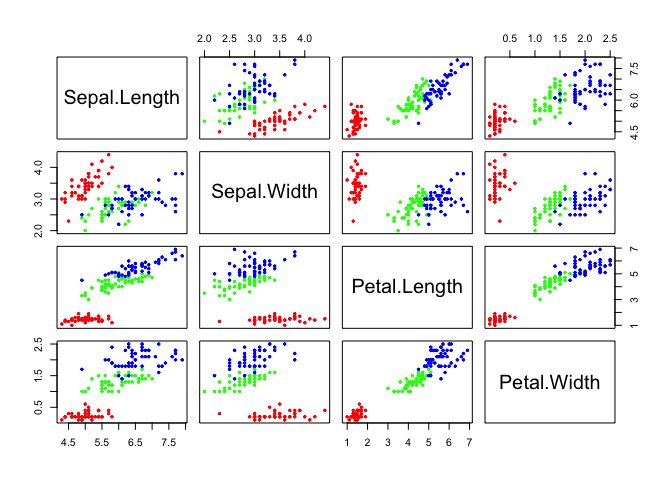

```r
my_cols=c("red","green","blue")
pairs(iris[,1:4],pch=19,cex=0.5,col=my_cols[iris$Species])
```

Here and in all subsequent plots the colour labels are: red=setosa, green=versicolor, blue=virginica. We see that the knowledge of a single feature, Petal Width or Petal Length, already allows us to predict quite well in which species a given plant belongs to. To improve the quality of our classifier, let us use the two most informative features, Petal Width and Petal Length, and plot one versus the other:

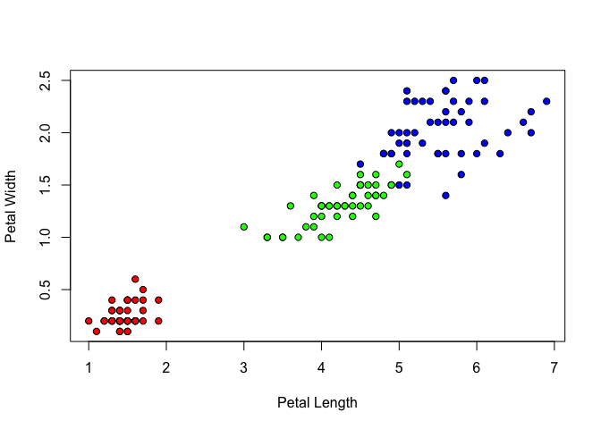

```r
plot(iris$Petal.Length,iris$Petal.Width,pch=21,bg=c("red","green","blue")[unclass(iris$Species)],xlab="Petal Length",ylab="Petal Width")
```

We see in the above plot that using only the Petal Length and Petal Width variables, one should be able to classify the plants by species. Anyway, we shall use the 4 measurements in the decision trees and random forests.

**Decision tree:** We are now going to build a decision tree to predict the species a given iris plant (represented by the four measurements Sepal Width, Sepal Length, Petal Length, Petal Width) belongs to. Try to go through all the steps and to understand what each step is doing.

Let us set the seed to some value to make the whole analysis reproducible, and split the Iris dataset into a training set, a validation set and a test set:

```r
seed=530
```

```r
data(iris)

set.seed(seed)
ind=sample(3,nrow(iris),replace=TRUE,prob=c(0.60,0.20, 0.20))

iris.training=iris[ind==1,]
iris.validation=iris[ind==2,]
iris.test=iris[ind==3,]
```

Make the decision tree model using the entropy as the impurity index, and (minsplit=10, minbucket=5) as stopping rules:

```r
set.seed(seed)
decision_tree=rpart(data=iris.training,Species~Sepal.Width+Sepal.Length+Petal.Length+Petal.Width,method="class",control=rpart.control(minsplit=10,minbucket=5),parms=list(split="information"))
```

Here the seed variable controls the internal random generator that is used by the decision tree algorithm (for example for selecting one of the best questions if there are several questions with the same largest information gain).

**Comment:** To show all the possible options, you may type help(rpart) and help(rpart.control), or look at the R documentation:

https://stat.ethz.ch/R-manual/R-devel/library/rpart/html/rpart.html

https://stat.ethz.ch/R-manual/R-devel/library/rpart/html/rpart.control.html

https://cran.r-project.org/web/packages/rpart/rpart.pdf

https://cran.r-project.org/web/packages/rpart/vignettes/longintro.pdf

In particular, note that if you want to make a regression tree, you will need to set method=“anova”.

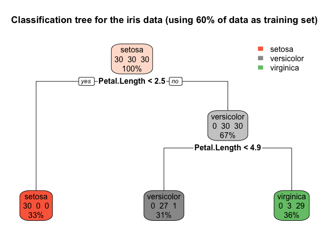

```r
rpart.plot(decision_tree,main="Classification tree for the iris data (using 60% of data as training set)",extra=101)
```

We see that the first two questions (or splits) of the decision tree use Petal Length. You may want to look again at the exploratory analysis that we have done before building the decision tree (the plot of Petal Width versus Petal Length). This may help you to understand better the iris tree structure.

Predict the species for the training dataset:

```r
predictions=predict(decision_tree,newdata=iris.training,type="class")
actuals=iris.training$Species
confusion.matrix.training=table(actuals,predictions)
print(confusion.matrix.training)
```

```
##             predictions
## actuals      setosa versicolor virginica
##   setosa         30          0         0
##   versicolor      0         27         3
##   virginica       0          1        29
```

This confusion matrix shows that the decision tree has made 4 mistakes in 90 preditions.

The corresponding training accuracy:

```r
accuracy.training=sum(diag(confusion.matrix.training))/sum(confusion.matrix.training)
print(accuracy.training)
```

```
## [1] 0.9555556
```

Predict the species for the validation dataset:

```r
predictions=predict(decision_tree,newdata=iris.validation,type="class")
actuals=iris.validation$Species
confusion.matrix.validation=table(actuals,predictions)
print(confusion.matrix.validation)
```

```
##             predictions
## actuals      setosa versicolor virginica
##   setosa         10          0         0
##   versicolor      0          9         1
##   virginica       0          2        10
```

This confusion matrix shows that the decision tree has made 3 mistakes in 32 preditions.

Let us finally compute the validation accuracy of the tree:

```r
accuracy.validation=sum(diag(confusion.matrix.validation))/sum(confusion.matrix.validation)
print(accuracy.validation)
```

```
## [1] 0.90625
```

Above we used (minsplit=10, minbucket=5) as stopping rules. Let us now use the cost complexity pruning method instead to find the best tree:

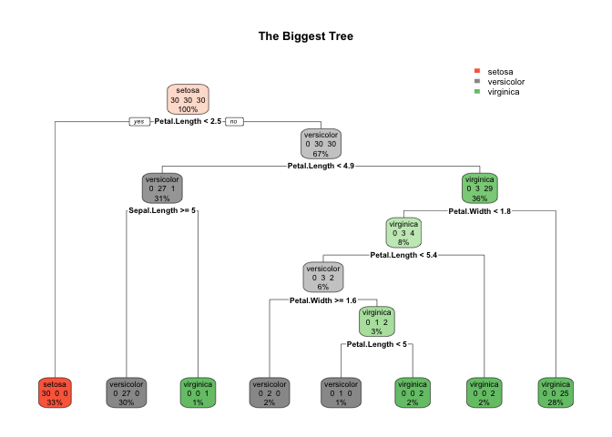

```r
set.seed(seed)
decision_tree=rpart(data=iris.training,Species~Sepal.Width+Sepal.Length+Petal.Length+Petal.Width,method="class",control=rpart.control(minsplit=1,minbucket=1,cp=0),parms=list(split="information"))
rpart.plot(decision_tree,main="The Biggest Tree",extra=101)
```

This is the biggest tree possible. We now need to prune this tree up to the smallest cross-validation error:

```r
printcp(decision_tree)
```

```
##
## Classification tree:
## rpart(formula = Species ~ Sepal.Width + Sepal.Length + Petal.Length +
##     Petal.Width, data = iris.training, method = "class", parms = list(split = "information"),
##     control = rpart.control(minsplit = 1, minbucket = 1, cp = 0))
##
## Variables actually used in tree construction:
## [1] Petal.Length Petal.Width  Sepal.Length
##
## Root node error: 60/90 = 0.66667
##
## n= 90
##
##         CP nsplit rel error  xerror     xstd
## 1 0.500000      0  1.000000 1.13333 0.067951
## 2 0.433333      1  0.500000 0.66667 0.078567
## 3 0.016667      2  0.066667 0.10000 0.039441
## 4 0.012500      3  0.050000 0.15000 0.047434
## 5 0.000000      7  0.000000 0.16667 0.049690
```

Here “cp” is the minimum of the cost complexity pruning parameter, that was written as alpha in the lectures, for which the pruning happens, “nsplit” is the number of splits (or questions) that are present in the pruned tree, and “xerror” is the validation error associated to the pruned tree. As we have seen in the lectures, the cp values control the size of the tree (a greater cp value implies fewer questions in the tree).

Let us make some plots of this table:

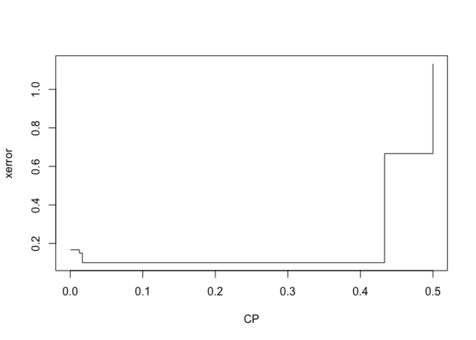

```r
plot(decision_tree$cptable[,"CP"],decision_tree$cptable[,"xerror"],type="S",xlab="CP",ylab="xerror")
```

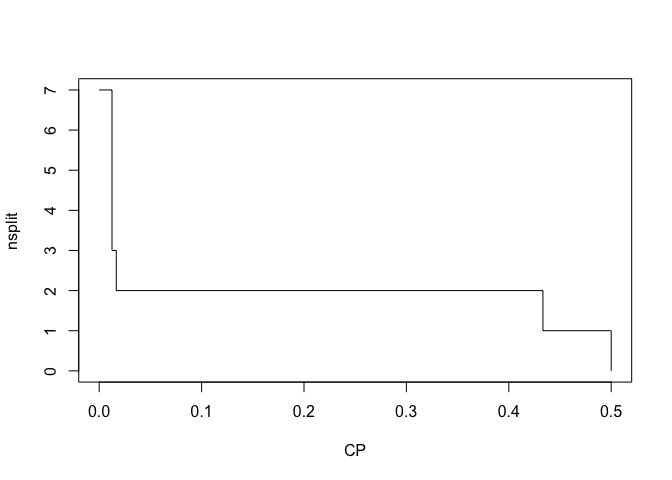

```r
plot(decision_tree$cptable[,"CP"],decision_tree$cptable[,"nsplit"],type="S",xlab="CP",ylab="nsplit")
```

**Comment:** To be more precise, the program uses K-fold cross-validation (with K=10) to compute the cross-validation error “xerror” and its standard deviation “xstd”. This method divides the training dataset into K folds, where K-1 folds are used as training and the remaining Kth fold is used as validation. The cross-validation error is obtained as the average error on the data in the left-out Kth fold.

From this table, we can select the cp value associated to the lowest validation error (cp=0.016667) and use it to prune the tree in an optimal way:

```r
cp_best=decision_tree$cptable[which.min(decision_tree$cptable[,"xerror"]),"CP"]
print(cp_best)
```

```
## [1] 0.01666667
```

**Comment:** In cases where a small change in cp implies a large change in nplits, you may use the “1SE rule”. This rule says that you should look for the minimum of xerror but then go up 1SE (given by “xstd”) because that tree will be less complex. For example, that would suggest selecting a tree (an upper row with fewer splits) associated to the xerror = 0.10000 + 1 * 0.0394410 = 0.139441. This is not the case for the Iris dataset.

**Comment:** There is another equivalent way to choose cp, which consists basically at looking at an “average plot” version of the above table:

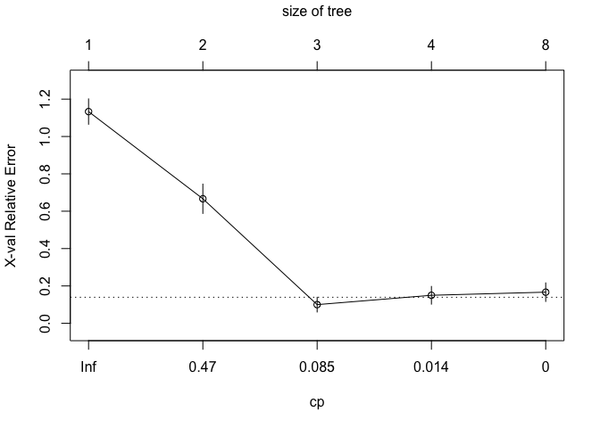

```r
plotcp(decision_tree)
```

The vertical axis “X-val Relative Error” corresponds to “xerror” in the previous table. There is a subtlety for the horizontal axis. Indeed the cp values shown in the plot are actually the geometric means of two consecutive cp values in the table above: cp_plot_n = sqrt(cp_table_n * cp_table_n-1), with n = 1, 2, 3, 4, 5 and cp_table_0 = infinity or Inf. For example, cp_plot_3 = sqrt(0.016667*0.433333) = 0.085. From this plot, we would choose the best cp as 0.085. Looking at the previous plots “xerror” versus “CP” and “nsplit” versus “CP”, we see that all the values of cp in the interval [0.016667, 0.433333[ give the same pruned tree (nsplit=2), and thus cp=0.085 (the geometic mean of 0.016667 and 0.433333) leads to the same pruned tree as with cp_best = 0.016667. Let me remind you that the “size of tree” is defined as the number of leaves in the tree. The horizontal line is drawn 1SE above the minimum of the curve.

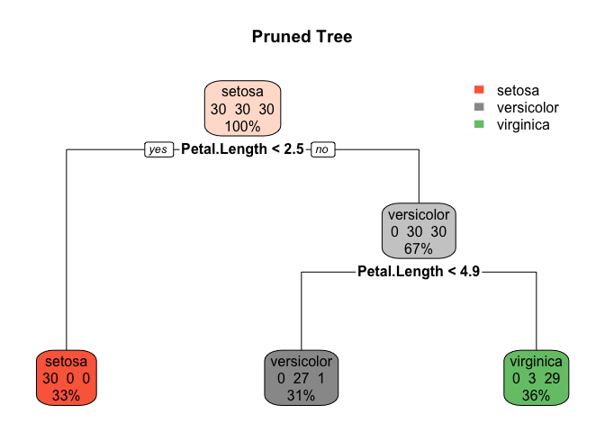

```r
pruned_tree=prune(decision_tree,cp=cp_best)
rpart.plot(pruned_tree,main="Pruned Tree",extra=101)
```

We see that we obtain the same tree as with (minsplit=10, minbucket=5) as stopping rules.

**Questions:** Play around with different hyperparameter values [split (“gini”), minsplit, minbucket, Species (Petal.Length+Petal.Width)] in the hope that your model will perform better.

**Random forest:** Let us now build a random forest to predict the species a given iris plant belongs to. Try to go through all the steps and to understand what each step is doing.

Build the random forest model using the Gini index (the library randomForest can only consider Gini as the impurity index), 200 trees, sample of size 60 with replacement, m=sqrt(4)=2 input variables for each question (or split) of the tree:

```r
set.seed(seed)
random_forest=randomForest(data=iris.training,Species~Sepal.Width+Sepal.Length+Petal.Length+Petal.Width,ntree=200,sampsize=60,replace=TRUE,mtry=2)
```

Here the seed variable controls the internal random generator that is used by the random forest algorithm (for example for selecting data points from the training dataset to make the M bootstrap training subsets or for selecting m=2 features from the p=4 iris features while building the M trees).

**Comment:** To show all the possible options, you may type help(randomForest) or look at the R documentation: https://cran.r-project.org/web/packages/randomForest/randomForest.pdf

```r
print(random_forest)
```

```
##
## Call:
##  randomForest(formula = Species ~ Sepal.Width + Sepal.Length +      Petal.Length + Petal.Width, data = iris.training, ntree = 200,      sampsize = 60, replace = TRUE, mtry = 2)
##                Type of random forest: classification
##                      Number of trees: 200
## No. of variables tried at each split: 2
##
##         OOB estimate of  error rate: 7.78%
## Confusion matrix:
##            setosa versicolor virginica class.error
## setosa         30          0         0   0.0000000
## versicolor      0         27         3   0.1000000
## virginica       0          4        26   0.1333333
```

The above confusion matrix and the out-of-bag (OOB) error rate [7/90*100=7.78%] are obtained as follows: for each plant in the training dataset, make a random forest prediction using only the trees that did not use that particular plant in their bootstrap training subset. In the OOB approach, the random forest model is thus used to predict the data NOT drawn (the “out-of-bag” sample).

Let us plot the OOB misclassification error rate as a function of the number of trees used in the random forest:

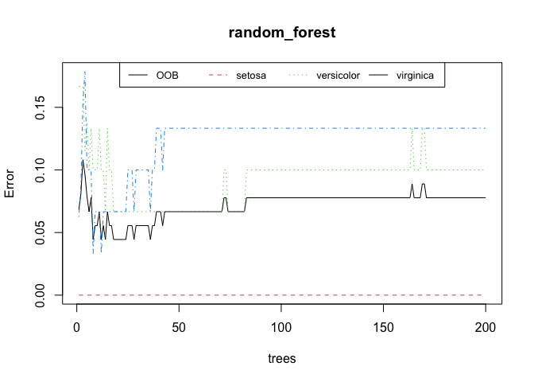

```r
plot(random_forest)
legend("top",cex=0.8,legend=colnames(random_forest$err.rate),lty=c(1,2,3),col=c(1,2,3),horiz=T)
```

The x-axis is the “number of trees” and the y-axis is the “OOB misclassification error rates”. The black solid line represents the overall OOB error. The colour lines are the class errors (one for each species: red=Setosa, green=Versicolor and blue=Virginica). We see that we should use about 100 trees (the Random Forest models with less than 100 trees have lower OOB errors but seem rather unstable, so we prefer the stable Random Forest model with about 100 trees):

```r
set.seed(seed)
random_forest=randomForest(data=iris.training,Species~Sepal.Width+Sepal.Length+Petal.Length+Petal.Width,ntree=100,sampsize=60,replace=TRUE,mtry=2)
```

**Comment:** The advantage of using the oob accuracy instead of the validation accuracy to determine the best number of trees is that you do not need to keep a validation dataset on the side. If you only use random forests, then you may merge the above training and validation datasets and use oob accuracy (or k-fold cross-validation accuracy) to select the best values for all the hyperparameters. However, in our case, we want to compare the decision tree with the random forest, so we need to use a common separate validation dataset.

Predict the species for the training dataset with the random forest model:

```r
predictions=predict(random_forest,newdata=iris.training,type="class")
actuals=iris.training$Species
confusion.matrix.training=table(actuals,predictions)
print(confusion.matrix.training)
```

```
##             predictions
## actuals      setosa versicolor virginica
##   setosa         30          0         0
##   versicolor      0         30         0
##   virginica       0          0        30
```

This confusion matrix shows that the random forest has made 0 mistake in 90 preditions.

The corresponding training accuracy:

```r
accuracy.training=sum(diag(confusion.matrix.training))/sum(confusion.matrix.training)
print(accuracy.training)
```

```
## [1] 1
```

We see 100% accuracy: the random forest has perfectly learned the training data.

Predict the species for the validation dataset:

```r
predictions=predict(random_forest,newdata=iris.validation,type="class")
actuals=iris.validation$Species
confusion.matrix.validation=table(actuals,predictions)
print(confusion.matrix.validation)
```

```
##             predictions
## actuals      setosa versicolor virginica
##   setosa         10          0         0
##   versicolor      0         10         0
##   virginica       0          2        10
```

This confusion matrix shows that the random forest has made 2 mistake in 32 preditions.

Finally the validation accuracy:

```r
accuracy.validation=sum(diag(confusion.matrix.validation))/sum(confusion.matrix.validation)
print(accuracy.validation)
```

```
## [1] 0.9375
```

We see that the validation accuracy of the random forest is slighly higher than that of the decision tree.

Compute and plot the importance (of all the variables):

```r
importance(random_forest)
```

```
##              MeanDecreaseGini
## Sepal.Width         0.8385237
## Sepal.Length        4.7838635
## Petal.Length       19.0684095
## Petal.Width        14.6362033
```

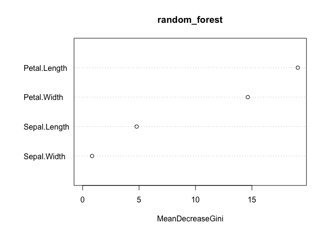

```r
varImpPlot(random_forest)
```

We see that the Petal Length and Petal Width are the two most important predictors. To understand this results, you may want to look back at the previous decision tree and plot of Petal Length versus Petal Width.

**Questions:** Play around with different parameter values (ntree, replace (FALSE), sampsize (size of sample to draw), mtry (the number of variables randomly sampled as candidates at each question (or split); default: sqrt(4)=2), and the seed (initializing the random generator in the random forest)] in the hope that your model will perform better.

Once you have found the best model (the one with the highest validation accuracy), you may apply it to the test dataset. In the present situation, the random forest gave the largest validation accuracy. Thus

```r
predictions=predict(random_forest,newdata=iris.test,type="class")
actuals=iris.test$Species
confusion.matrix.test=table(actuals,predictions)
print(confusion.matrix.test)
```

```
##             predictions
## actuals      setosa versicolor virginica
##   setosa         10          0         0
##   versicolor      0         10         0
##   virginica       0          0         8
```

Finally the test accuracy:

```r
accuracy.test=sum(diag(confusion.matrix.test))/sum(confusion.matrix.test)
print(accuracy.test)
```

```
## [1] 1
```

**BONUS 1 - The classification regions and associated decision boundaries:** We will use a home made decision plot funtion written by Michael Hahsler:

```r
decisionplot=function(model,data,class=NULL,predict_type="class",resolution=100,showgrid=TRUE, ...) {

  if(!is.null(class)) cl=data[,class] else cl=1
  data=data[,1:2]
  k=length(unique(cl))

  plot(data,col=as.integer(cl)+1L,pch=as.integer(cl)+1L, ...)

  r=sapply(data,range,na.rm=TRUE)
  xs=seq(r[1,1],r[2,1],length.out=resolution)
  ys=seq(r[1,2],r[2,2],length.out=resolution)
  g=cbind(rep(xs, each=resolution),rep(ys,time=resolution))
  colnames(g)=colnames(r)
  g=as.data.frame(g)

  p=predict(model,g,type=predict_type)
  if(is.list(p)) p=p$class
  p=as.factor(p)

  if(showgrid) points(g,col=as.integer(p)+1L,pch=".")

  z=matrix(as.integer(p),nrow=resolution,byrow=TRUE)
  contour(xs,ys,z,add=TRUE,drawlabels=FALSE,lwd=2,levels=(1:(k-1))+.5)

  invisible(z)
}
```

**Decision Trees:** Let us make the decision tree model with only Petal.Length and Petal.Width:

```r
set.seed(seed)
decision_tree=rpart(data=iris.training,Species~Petal.Length+Petal.Width,method="class",control=rpart.control(minsplit=10,minbucket=5),parms=list(split="information"))
```

Let us plot the decision boundaries (with corresponding predicted species domains) based on the training datatset, and add the training data points:

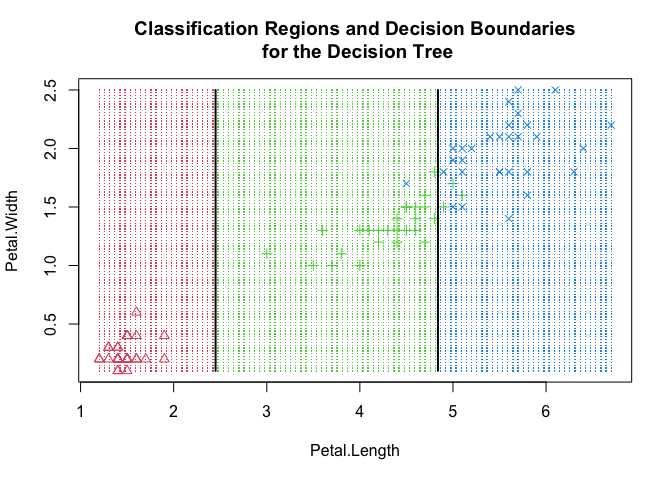

```r
df=iris.training[,c("Petal.Length", "Petal.Width", "Species")]
decisionplot(decision_tree,df,class="Species",main="Classification Regions and Decision Boundaries\n for the Decision Tree")
```

**Random Forests:** Let us make the random forest model with only Petal.Length and Petal.Width:

```r
set.seed(seed)
random_forest=randomForest(data=iris.training,Species~Petal.Length+Petal.Width,ntree=100,sampsize=60,replace=TRUE,mtry=2)
```

Let us plot the decision boundaries (with corresponding predicted species domains) based on the training datatset, and add the training data points:

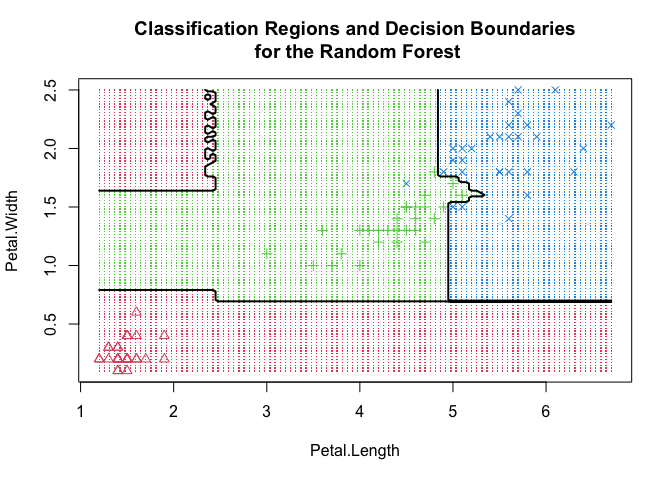

```r
df=iris.training[,c("Petal.Length", "Petal.Width", "Species")]
decisionplot(random_forest,df,class="Species",main="Classification Regions and Decision Boundaries\n for the Random Forest")
```

**BONUS 2 - Let us find the best hyperparameters by using the Grid Search method**

Choose the hyperparameters you want to tune, and the corresponding range of values:

```r
hyper=list(maxdepth=1:5,minsplit=1:10,minbucket=1:5)
gs=tidyr::expand_grid(!!!hyper)
```

Create a function to go through our grid search hyperparameter combinations:

```r
model=function(...) {
  set.seed(seed)
  rpart(data=iris.training,Species~Petal.Length+Petal.Width,method="class",control=rpart.control(...),parms=list(split="information"))
}
```

Iterate through the values of the hyperparameters and fit the corresponding models:

```r
gs=gs %>% mutate(fit=pmap(gs,model))
```

```r
validation_features=iris.validation %>% select(-Species)
validation_labels=iris.validation$Species
```

Create a function to compute the accuracy:

```r
compute_accuracy=function(fit,validation_features,validation_labels) {
  predicted=predict(fit,validation_features,type="class")
  mean(predicted==validation_labels)
}
```

Compute the validation accuracy of all the tree models considered in the grid search:

```r
gs=gs %>% mutate(validation_accuracy=map_dbl(fit,compute_accuracy,validation_features,validation_labels))
```

Sort results by high accuracy, more minsplit and less maxdepth:

```r
gs=gs %>% arrange(desc(validation_accuracy),desc(minsplit),maxdepth)
head(gs %>% select(-fit))
```

```
## # A tibble: 6 × 4
##   maxdepth minsplit minbucket validation_accuracy
##      <int>    <int>     <int>               <dbl>
## 1        2       10         1               0.906
## 2        2       10         2               0.906
## 3        2       10         3               0.906
## 4        2       10         4               0.906
## 5        2       10         5               0.906
## 6        3       10         1               0.906
```

The best tree has hyperameters maxdepth=2 and minsplit=10, with several possible values for minbucket.

Show the best tree found by the Grid Search method:

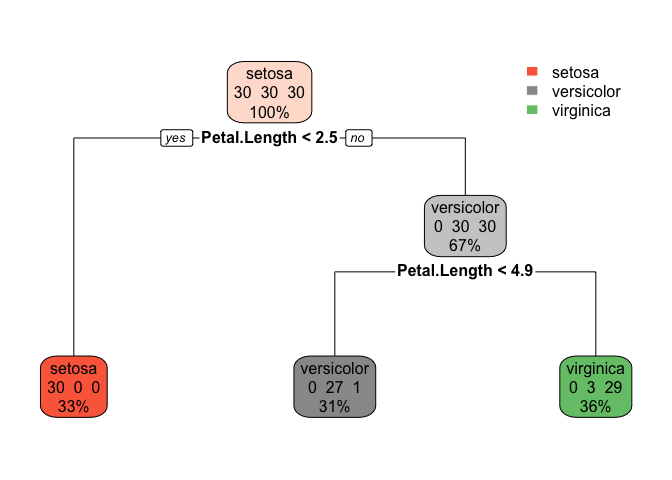

```r
best_tree=gs$fit[[1]]
rpart.plot(best_tree,extra=101)
```